# PISA 2012 Dataset Exploration

## Preliminary Wrangling

```python
# import all packages and set plots to be embedded inline
import numpy as np
import pandas as pd
import matplotlib.pyplot as plt
import seaborn as sb

%matplotlib inline
```

```python
# load in the dataset into a pandas dataframe
pisa_full = pd.read_csv('pisa2012.csv', sep=',', encoding='latin-1',error_bad_lines=False, index_col=False, dtype='unicode')
```

```python
# high-level overview of data shape and composition
print(pisa_full.shape)
print(pisa_full.dtypes)
print(pisa_full.head(10))
```

```
(485490, 636)
Unnamed: 0    object
CNT           object
SUBNATIO      object
STRATUM       object
OECD          object
               ...
W_FSTR80      object
WVARSTRR      object
VAR_UNIT      object
SENWGT_STU    object
VER_STU       object
Length: 636, dtype: object
  Unnamed: 0      CNT SUBNATIO  STRATUM      OECD       NC SCHOOLID STIDSTD  \
0          1  Albania  0080000  ALB0006  Non-OECD  Albania  0000001   00001
1          2  Albania  0080000  ALB0006  Non-OECD  Albania  0000001   00002
2          3  Albania  0080000  ALB0006  Non-OECD  Albania  0000001   00003
3          4  Albania  0080000  ALB0006  Non-OECD  Albania  0000001   00004
4          5  Albania  0080000  ALB0006  Non-OECD  Albania  0000001   00005
5          6  Albania  0080000  ALB0006  Non-OECD  Albania  0000001   00006
6          7  Albania  0080000  ALB0006  Non-OECD  Albania  0000001   00007
7          8  Albania  0080000  ALB0006  Non-OECD  Albania  0000001   00008
8          9  Albania  0080000  ALB0006  Non-OECD  Albania  0000001   00009
9         10  Albania  0080000  ALB0005  Non-OECD  Albania  0000002   00010

  ST01Q01 ST02Q01  ... W_FSTR75 W_FSTR76 W_FSTR77 W_FSTR78 W_FSTR79 W_FSTR80  \
0      10       1  ...  13.7954  13.9235  13.1249  13.1249   4.3389  13.0829
1      10       1  ...  13.7954  13.9235  13.1249  13.1249   4.3389  13.0829
2       9       1  ...  12.7307  12.7307  12.7307  12.7307   4.2436  12.7307
3       9       1  ...  12.7307  12.7307  12.7307  12.7307   4.2436  12.7307
4       9       1  ...  12.7307  12.7307  12.7307  12.7307   4.2436  12.7307
5       9       1  ...  12.7307  12.7307  12.7307  12.7307   4.2436  12.7307
6      10       1  ...  13.7954  13.9235  13.1249  13.1249   4.3389  13.0829
7      10       1  ...  14.4599  14.6374  15.8728  15.8728   5.2248  15.2579
8       9       1  ...  12.7307  12.7307  12.7307  12.7307   4.2436  12.7307
9      10       1  ...   3.3844  10.1533   3.3844  10.1533  10.1533  10.1533

  WVARSTRR VAR_UNIT SENWGT_STU  VER_STU
0       19        1     0.2098  22NOV13
1       19        1     0.2098  22NOV13
2       19        1     0.1999  22NOV13
3       19        1     0.1999  22NOV13
4       19        1     0.1999  22NOV13
5       19        1     0.1999  22NOV13
6       19        1     0.2098  22NOV13
7       19        1     0.2322  22NOV13
8       19        1     0.1999  22NOV13
9       74        2     0.1594  22NOV13

[10 rows x 636 columns]
```

### Structure of the dataset and the feature of interest

The dataset contains 636 columns and 485490 row entries. Each row represents a student performance entry. The student performances are splitted into 3 main categories: Mathematics (PV1MATH to PV5MATH), Reading (PV1READ to PV5READ) and Science (PV1SCIE to PV5SCIE). All these columns are numeric but have data type object. I'll change the datatype of the columns during the analysis when needed.

Besides the performance variables, the dataset consists of various other variables such as living country, parent qualifications, possessions, subjective norms, experiences and many more.

Due to the large amount of data, this analysis will only concentrate on certain variables. For this purpose, I will create a new subset with the data of interest.

The main performance variable will be mathematics. I will try to find the features what best predict a mathematic performance above average.  
The other features will be:

- gender (ST04Q01)
- immigration status (IMMIG)
- attributions to failure in mathematics (FAILMAT)
- mathematics anxiety (ANXMAT)
- subjective norms in mathematics (SUBNORM)
- instrumental motivation for mathematics (INSTMOT)
- mathematics interest (INTMAT)
- home educational resources (HEDRES)
- out of school lessons in mathematics (ST55Q02)
- Students’ responses regarding parental education ('MISCED' & 'FISCED')
- How many books at home (ST28Q01)

Extracts from the PISA 2012 Technical Report are used to decribe these variables in more detail<sup>2</sup>.

```python
# Reduce the orginal dataset to the choosen columns
pisa = pisa_full.loc[:, ['PV1MATH', 'PV2MATH', 'PV3MATH', 'PV4MATH', 'PV5MATH', 'CNT',
                 'FAILMAT', 'ST44Q01', 'ST44Q03', 'ST44Q04', 'ST44Q05', 'ST44Q07', 'ST44Q08',
                 'ANXMAT', 'ST42Q01', 'ST42Q03', 'ST42Q05', 'ST42Q08', 'ST42Q10',
                 'SUBNORM', 'ST35Q01', 'ST35Q02', 'ST35Q03', 'ST35Q04', 'ST35Q05', 'ST35Q06',
                 'INSTMOT', 'ST29Q02', 'ST29Q05', 'ST29Q07', 'ST29Q08',
                 'INTMAT', 'ST29Q01', 'ST29Q03', 'ST29Q04', 'ST29Q06',
                 'HEDRES', 'ST26Q01', 'ST26Q03', 'ST26Q04', 'ST26Q05',
                 'ST55Q02',
                 'ST04Q01', 'IMMIG',
                 'MISCED', 'FISCED', 'ST28Q01']]
```

```python
# high-level overview of data shape and composition after reducing
print(pisa.shape)
print(pisa.dtypes)
print(pisa.head(10))
```

```
(485490, 47)
PV1MATH    object
PV2MATH    object
PV3MATH    object
PV4MATH    object
PV5MATH    object
CNT        object
FAILMAT    object
ST44Q01    object
ST44Q03    object
ST44Q04    object
ST44Q05    object
ST44Q07    object
ST44Q08    object
ANXMAT     object
ST42Q01    object
ST42Q03    object
ST42Q05    object
ST42Q08    object
ST42Q10    object
SUBNORM    object
ST35Q01    object
ST35Q02    object
ST35Q03    object
ST35Q04    object
ST35Q05    object
ST35Q06    object
INSTMOT    object
ST29Q02    object
ST29Q05    object
ST29Q07    object
ST29Q08    object
INTMAT     object
ST29Q01    object
ST29Q03    object
ST29Q04    object
ST29Q06    object
HEDRES     object
ST26Q01    object
ST26Q03    object
```

[output cut: 43 more lines]

```
9     Yes     Yes                           Less than 2 hours a week  Female

    IMMIG             MISCED             FISCED              ST28Q01
0  Native  ISCED 3A, ISCED 4  ISCED 3A, ISCED 4          0-10 books
1  Native        ISCED 5A, 6  ISCED 3A, ISCED 4       201-500 books
2  Native        ISCED 5A, 6        ISCED 5A, 6  More than 500 books
3  Native        ISCED 3B, C        ISCED 5A, 6         11-25 books
4  Native               None  ISCED 3A, ISCED 4       101-200 books
5  Native        ISCED 3B, C            ISCED 2          0-10 books
6  Native        ISCED 5A, 6  ISCED 3A, ISCED 4          0-10 books
7  Native        ISCED 5A, 6        ISCED 5A, 6        26-100 books
8  Native  ISCED 3A, ISCED 4        ISCED 5A, 6        26-100 books
9  Native  ISCED 3A, ISCED 4  ISCED 3A, ISCED 4         11-25 books

[10 rows x 47 columns]
```

## Univariate Exploration

### Main feature of interest: mathematic performance

PISA reports student performance through plausible values.  
It has been noted that<sup>1</sup>:

> “The simplest way to describe plausible values is to say that plausible values are a representation of the range of abilities that a student might reasonably have. […] Instead of directly estimating a student’s ability $\theta$ , a probability distribution for a student’s $\theta$ is estimated. That is, instead of obtaining a point estimate for $\theta$ , like a WLE, a range of possible values for a student’s $\theta$ , with an associated probability for each of these values is estimated. Plausible values are random draws from this (estimated) distribution for a student’s $\theta$ ” (Wu and Adams, 2002).

> The probability distribution for a student’s $\theta$ can be based on the cognitive data only, i.e. the item response pattern, but can also include additional information, such as student gender, social background, and so on. The probability distribution becomes therefore conditioned by this additional information. (OECD, 2002c).

Let's compare all 5 mathematic performances.  
As almost all columns have as a datatype string, I create a function for changing datatypes to float when needed:

```python
# function to change the value type to float
def change_to_float(col):
    pisa[col] = pisa[col].astype(float)
```

```python
change_to_float('PV1MATH')
change_to_float('PV2MATH')
change_to_float('PV3MATH')
change_to_float('PV4MATH')
change_to_float('PV5MATH')
```

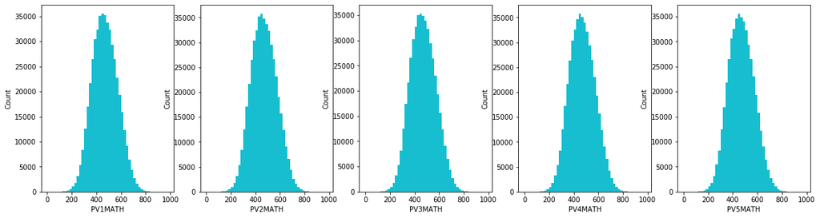

```python
# comparison of the 5 variables that represent mathematical plausible values
base_color = sb.color_palette()[9]
binsize = 20
bins = np.arange(0, pisa['PV1MATH'].max()+binsize, binsize)

plt.figure(figsize=[20, 5])

plt.subplot(1,5,1)
plt.hist(data = pisa, x = 'PV1MATH', bins = bins, color=base_color)
plt.xlabel('PV1MATH')
plt.ylabel('Count')

plt.subplot(1,5,2)
plt.hist(data = pisa, x = 'PV2MATH', bins = bins, color=base_color)
plt.xlabel('PV2MATH')
plt.ylabel('Count')

plt.subplot(1,5,3)
plt.hist(data = pisa, x = 'PV3MATH', bins = bins, color=base_color)
plt.xlabel('PV3MATH')
plt.ylabel('Count')

plt.subplot(1,5,4)
plt.hist(data = pisa, x = 'PV4MATH', bins = bins, color=base_color)
plt.xlabel('PV4MATH')
plt.ylabel('Count')

plt.subplot(1,5,5)
plt.hist(data = pisa, x = 'PV5MATH', bins = bins, color=base_color)
plt.xlabel('PV5MATH')
plt.ylabel('Count')
plt.show()
```

We can see here that all variables have a similar distribution. For reasons of simplification, I'll only use the variable PV1MATH in my analysis.

### Features what could best predict a mathematic performance:

### Gender (ST04Q01)

```python
# unique values in column
pisa['ST04Q01'].unique()
```

```
array(['Female', 'Male'], dtype=object)
```

```python
# function to add percentages into the plotbars
n_points = pisa.shape[0]
def pct_labels(col):
    cat_counts = pisa[col].value_counts()
    locs, labels = plt.xticks()
    for loc, label in zip(locs, labels):
        count=cat_counts[label.get_text()]
        pct_string = '{:0.1f}%'.format(100*count/n_points)
        plt.text(loc, count-(count/100*50), pct_string, ha='center')
```

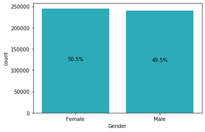

```python
# standard-scaled plot
sb.countplot(data = pisa, x = 'ST04Q01', color=base_color)
pct_labels('ST04Q01')
plt.xlabel('Gender');
```

The repartition of girls and boys is very similar.

### Immigration Status (IMMIG)

```python
# unique values in column
pisa['IMMIG'].unique()
```

```
array(['Native', nan, 'Second-Generation', 'First-Generation'],
      dtype=object)
```

```python
# data preparation - Change values into categorical data
level_order = ['Native', 'First-Generation', 'Second-Generation']
ordered_cat = pd.api.types.CategoricalDtype(ordered=True, categories = level_order)
pisa['IMMIG'] = pisa['IMMIG'].astype(ordered_cat)
```

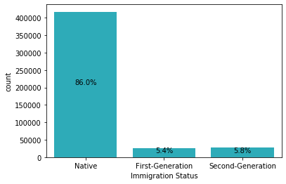

```python
# standard-scaled plot
sb.countplot(data = pisa,x = 'IMMIG', color=base_color)
pct_labels('IMMIG')
plt.xlabel('Immigration Status');
```

A large proportion of the student body has no migration background.

### Attributions to failure in mathematics (FAILMAT)

#### Information from Pisa 2012 Technical Report:

A new scale indicating attributions to failure in mathematics (FAILMAT) was developed in PISA 2012 based on six items. Table 16.15 of the pisa technical report<sup>2</sup> shows the item wording and the international item parameters for this scale. The response categories were “Very likely”, “Likely”, “Slightly likely”, “Not at all likely”. All items were reversed, so the higher difficulty corresponds to the higher level of external attribution of failure such as bad luck, bad guesses or the teacher.

Question:  
Suppose that you are a student in the following situation: Each week, your mathematics teacher gives a short quiz. Recently you have done badly on these quizzes. Today you are trying to figure out why. How likely are you to have these thoughts or feelings in this situation?  
ST44Q01 a) I’m not very good at solving mathematics problems  
ST44Q03 b) My teacher did not explain the concepts well this week  
ST44Q04 c) This week I made bad guesses on the quiz  
ST44Q05 d) Sometimes the course material is too hard  
ST44Q07 e) The teacher did not get students interested in the material  
ST44Q08 f) Sometimes I am just unlucky

Items were coded as (1=0), (2=1), (3=2), (4=3). Total score was calculated as a ratio of a sum of all questions over maximum score of valid responses (questions with missing value did not contribute to max score)

Let's first analyse the data of this column:

```python
pisa['FAILMAT'].dtype
```

```
dtype('O')
```

```python
# change datatype to float
change_to_float('FAILMAT')
```

```python
pisa['FAILMAT'].describe()
```

```
count    314448.000000
mean         -0.013110
std           1.029037
min          -3.766600
25%          -0.530000
50%          -0.076000
75%           0.640000
max           3.906700
Name: FAILMAT, dtype: float64
```

```python
# sample of the columns belonging to FAILMAT
cols_failmat = ['ST44Q01', 'ST44Q03', 'ST44Q04', 'ST44Q05', 'ST44Q07', 'ST44Q08']
ordered_cat = pd.api.types.CategoricalDtype(ordered=True, categories = level_order)
pisa[pisa['FAILMAT'] == pisa['FAILMAT'].min()][cols_failmat].head()
```

|  | ST44Q01 | ST44Q03 | ST44Q04 | ST44Q05 | ST44Q07 | ST44Q08 |
| --- | --- | --- | --- | --- | --- | --- |
| 527 | Not at all likely | Not at all likely | Not at all likely | Not at all likely | Not at all likely | Not at all likely |
| 746 | Not at all likely | Not at all likely | Not at all likely | Not at all likely | Not at all likely | Not at all likely |
| 1948 | Not at all likely | Not at all likely | Not at all likely | Not at all likely | Not at all likely | Not at all likely |
| 2109 | Not at all likely | Not at all likely | Not at all likely | Not at all likely | Not at all likely | Not at all likely |
| 2177 | Not at all likely | Not at all likely | Not at all likely | Not at all likely | Not at all likely | Not at all likely |

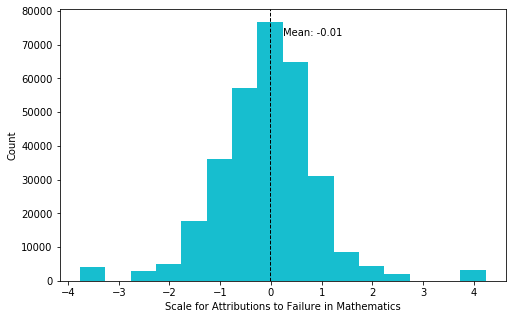

```python
# standard-scaled plot
binsize = 0.5
bins = np.arange(pisa['FAILMAT'].min(), pisa['FAILMAT'].max()+binsize, binsize)

plt.figure(figsize=[8, 5])
plt.hist(data = pisa, x = 'FAILMAT', bins = bins, color=base_color)
plt.axvline(pisa['FAILMAT'].mean(), color='k', linestyle='dashed', linewidth=1)
min_ylim, max_ylim = plt.ylim()
plt.text(pisa['FAILMAT'].mean()*-18.5, max_ylim*0.9, 'Mean: {:.2f}'.format(pisa['FAILMAT'].mean()))
plt.xlabel('Scale for Attributions to Failure in Mathematics')
plt.ylabel('Count')
plt.show()
```

The higher the value on the scale, the more agreement there was with the statements. The results about attributions to failure in mathematics are normaly distributed.  
Let's take a closer look at the single features belonging to FAILMAT:

```python
# data preparation - Change values into categorical data
level_order = ['Not at all likely', 'Slightly likely', 'Likely', 'Very   Likely']
ordered_cat = pd.api.types.CategoricalDtype(ordered=True, categories = level_order)
pisa[cols_failmat] = pisa[cols_failmat].astype(ordered_cat)
```

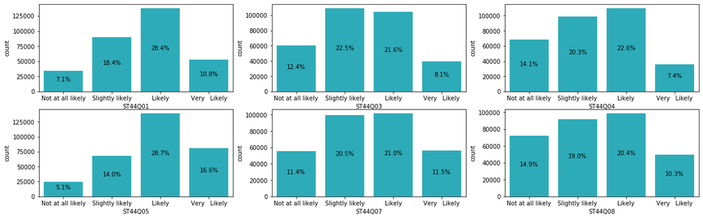

```python
# plots comparing the different features - Nan answers are not plotted
plt.figure(figsize=[20, 6])
plt.subplot(2,3,1)
sb.countplot(data = pisa, x = 'ST44Q01', color=base_color) # I'm not very good at solving mathematics problems
pct_labels('ST44Q01')
plt.subplot(2,3,2)
sb.countplot(data = pisa, x = 'ST44Q03', color=base_color) # My teacher did not explain the concepts well this week
pct_labels('ST44Q03')
plt.subplot(2,3,3)
sb.countplot(data = pisa, x = 'ST44Q04', color=base_color) # This week I made bad guesses on the quiz
pct_labels('ST44Q04')
plt.subplot(2,3,4)
sb.countplot(data = pisa, x = 'ST44Q05', color=base_color) # Sometimes the course material is too hard
pct_labels('ST44Q05')
plt.subplot(2,3,5)
sb.countplot(data = pisa, x = 'ST44Q07', color=base_color) # The teacher did not get students interested in the material
pct_labels('ST44Q07')
plt.subplot(2,3,6)
sb.countplot(data = pisa, x = 'ST44Q08', color=base_color) # Sometimes I am just unlucky
pct_labels('ST44Q08')
```

The most approved statements are: "Sometimes the course material is too hard" and "I’m not very good at solving mathematics problems"  
These statements are less approved: "My teacher did not explain the concepts well this week" and "This week I made bad guesses on the quiz"

### Mathematics Anxiety (ANXMAT)

#### Information from Pisa 2012 Technical Report:

Table 16.13 item parameters for mathematics anxiety (ANXMAT):  
The five items measuring mathematics anxiety (ANXMAT) that were used in the Main Survey of PISA 2012 had also been used in PISA 2003. Table 16.13 shows the item wording and the international item parameters for this scale. The response categories were “strongly agree”, “agree”, “disagree” and “strongly disagree”. All items were reversed, so the higher difficulty corresponds to the higher level of anxiety.

Thinking about studying mathematics: to what extent do you agree with the following statements?  
ST42Q01 a) I often worry that it will be difficult for me in mathematics classes  
ST42Q03 c) I get very tense when I have to do mathematics homework  
ST42Q05 e) I get very nervous doing mathematics problems  
ST42Q08 h) I feel helpless when doing a mathematics problem  
ST42Q10 j) I worry that I will get poor in mathematics

Items were reversely recoded as (4=0), (3=1), (2=2), (1=3).Total score was calculated as a ratio of a sum of all questions over maximum score of valid responses (questions with missing value did not contribute to max score).

Let's first analyse the data of this column:

```python
pisa['ANXMAT'].dtype
```

```
dtype('O')
```

```python
# change datatype to float
change_to_float('ANXMAT')
```

```python
pisa['ANXMAT'].describe()
```

```
count    314764.000000
mean          0.152647
std           0.955031
min          -2.370000
25%          -0.470000
50%           0.060000
75%           0.790000
max           2.550000
Name: ANXMAT, dtype: float64
```

```python
# sample of the columns belonging to ANXMAT
cols_anxmat = ['ST42Q01', 'ST42Q03', 'ST42Q05', 'ST42Q08', 'ST42Q10']
pisa[pisa['ANXMAT'] == pisa['ANXMAT'].max()][cols_anxmat].head()
```

|  | ST42Q01 | ST42Q03 | ST42Q05 | ST42Q08 | ST42Q10 |
| --- | --- | --- | --- | --- | --- |
| 12 | Strongly agree | Strongly agree | Strongly agree | Strongly agree | Strongly agree |
| 148 | Strongly agree | Strongly agree | Strongly agree | Strongly agree | Strongly agree |
| 178 | Strongly agree | Strongly agree | Strongly agree | Strongly agree | Strongly agree |
| 315 | Strongly agree | Strongly agree | Strongly agree | Strongly agree | Strongly agree |
| 406 | Strongly agree | Strongly agree | Strongly agree | Strongly agree | Strongly agree |

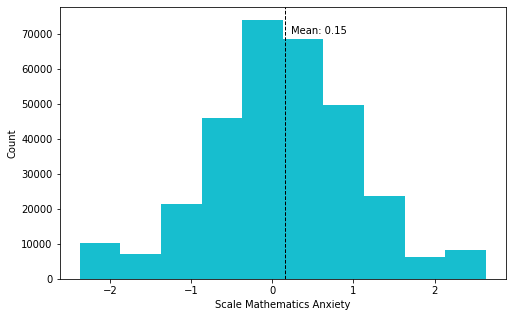

```python
# standard-scaled plot
binsize = 0.5
bins = np.arange(pisa['ANXMAT'].min(), pisa['ANXMAT'].max()+binsize, binsize)

plt.figure(figsize=[8, 5])
plt.hist(data = pisa, x = 'ANXMAT', bins = bins, color=base_color)
plt.axvline(pisa['ANXMAT'].mean(), color='k', linestyle='dashed', linewidth=1)
min_ylim, max_ylim = plt.ylim()
plt.text(pisa['ANXMAT'].mean()*1.5, max_ylim*0.9, 'Mean: {:.2f}'.format(pisa['ANXMAT'].mean()))
plt.xlabel('Scale Mathematics Anxiety')
plt.ylabel('Count')
plt.show()
```

The higher the value on the scale, the more agreement there was with the statements, which means that the anxiety is higher. The results about mathematics anxiety are normaly distributed.  
Let's take a closer look at the single features belonging to ANXMAT:

```python
# unique values in column
pisa['ST42Q01'].unique()
```

```
array(['Agree', nan, 'Strongly agree', 'Disagree', 'Strongly disagree'],
      dtype=object)
```

```python
# data preparation - Change values into categorical data
level_order = ['Strongly disagree', 'Disagree', 'Agree', 'Strongly agree']
ordered_cat = pd.api.types.CategoricalDtype(ordered=True, categories = level_order)
pisa[cols_anxmat] = pisa[cols_anxmat].astype(ordered_cat)
```

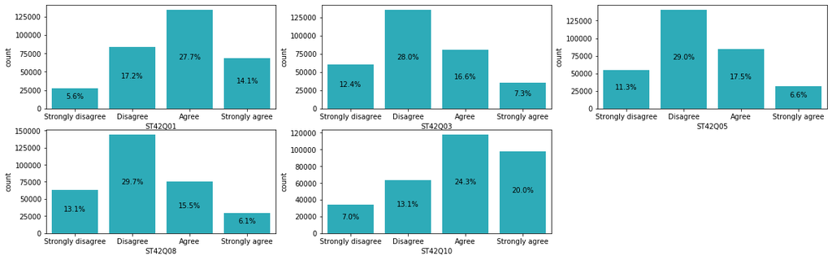

```python
# plots comparing the different features - nan values are excluded
plt.figure(figsize=[20, 6])
plt.subplot(2,3,1)
sb.countplot(data = pisa, x = 'ST42Q01', color=base_color) # I often worry that it will be difficult for me in mathematics classes
pct_labels('ST42Q01')
plt.subplot(2,3,2)
sb.countplot(data = pisa, x = 'ST42Q03', color=base_color) # I get very tense when I have to do mathematics homework
pct_labels('ST42Q03')
plt.subplot(2,3,3)
sb.countplot(data = pisa, x = 'ST42Q05', color=base_color) # I get very nervous doing mathematics problems
pct_labels('ST42Q05')
plt.subplot(2,3,4)
sb.countplot(data = pisa, x = 'ST42Q08', color=base_color) # I feel helpless when doing a mathematics problem
pct_labels('ST42Q08')
plt.subplot(2,3,5)
sb.countplot(data = pisa, x = 'ST42Q10', color=base_color) # I worry that I will get poor in mathematics
pct_labels('ST42Q10')
```

The less agreed statements are "I get very tense when I have to do mathematics homework", "I get very nervous doing mathematics problems" and "I feel helpless when doing a mathematics problem".  
The most agreed statements are "I often worry that it will be difficult for me in mathematics classes" and "I worry that I will get poor in mathematics".  
It's interesting to see, that anxiety is based more on worry than on tensity, nervosity or even helpless feelings.

### Subjective Norms in Mathematics (SUBNORM)

#### Information from Pisa 2012 Technical Report:

Table 16.11 item parameters for subjective norms in mathematics (SUBNORM):  
A new scale was created in PISA 2012 consisting of six items measuring subjective norms in mathematics (SUBNORM) in the Main Survey. Table 16.11 shows the item wording and the international item parameters for this scale. The response categories range from “Strongly agree”, “Agree”, “Disagree” to “Strongly disagree”. All items were reversed, so the higher difficulty corresponds to the higher level of agreement. Values for delta indicated that students found it harder to agree with the statement “My friends enjoy taking mathematics tests” (d = 1.36) whereas it was relatively easy to agree with the statement “My parents believe it’s important for me to study mathematics” (d = -1.08).

Thinking about how people important to you view mathematics: how strongly do you agree with the following statements?  
ST35Q01 a) Most of my friends do well in mathematics  
ST35Q02 b ) Most of my friends work hard at mathematics  
ST35Q03 c) My friends enjoy taking mathematics tests  
ST35Q04 d) My parents believe it’s important for me to study mathematics  
ST35Q05 e) My parents believe that mathematics is important for my career  
ST35Q06 f) My parents like mathematics

Items were reversely recoded as (4=0), (3=1), (2=2), (1=3).Total score was calculated as a ratio of a sum of all questions over maximum score of valid responses (questions with missing value did not contribute to max score)

Let's first analyse the data of this column:

```python
pisa['SUBNORM'].dtype
```

```
dtype('O')
```

```python
# change datatype to float
change_to_float('SUBNORM')
```

```python
pisa['SUBNORM'].describe()
```

```
count    316323.000000
mean          0.166138
std           1.088985
min          -4.245600
25%          -0.385200
50%          -0.045500
75%           0.660200
max           3.858700
Name: SUBNORM, dtype: float64
```

```python
# sample of the columns belonging to SUBNORM
cols_subnorm = ['ST35Q01', 'ST35Q02', 'ST35Q03', 'ST35Q04', 'ST35Q05', 'ST35Q06']
pisa[pisa['SUBNORM'] == pisa['SUBNORM'].min()][cols_subnorm].head()
```

|  | ST35Q01 | ST35Q02 | ST35Q03 | ST35Q04 | ST35Q05 | ST35Q06 |
| --- | --- | --- | --- | --- | --- | --- |
| 1381 | Strongly disagree | Strongly disagree | Strongly disagree | Strongly disagree | Strongly disagree | Strongly disagree |
| 5351 | Strongly disagree | Strongly disagree | Strongly disagree | Strongly disagree | Strongly disagree | Strongly disagree |
| 5512 | Strongly disagree | Strongly disagree | Strongly disagree | Strongly disagree | Strongly disagree | Strongly disagree |
| 5788 | Strongly disagree | Strongly disagree | Strongly disagree | Strongly disagree | Strongly disagree | Strongly disagree |
| 5965 | Strongly disagree | Strongly disagree | Strongly disagree | Strongly disagree | Strongly disagree | Strongly disagree |

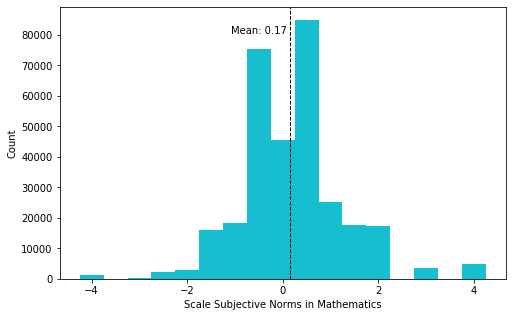

```python
# standard-scaled plot
binsize = 0.5
bins = np.arange(pisa['SUBNORM'].min(), pisa['SUBNORM'].max()+binsize, binsize)

plt.figure(figsize=[8, 5])
plt.hist(data = pisa, x = 'SUBNORM', bins = bins, color=base_color)
plt.axvline(pisa['SUBNORM'].mean(), color='k', linestyle='dashed', linewidth=1)
min_ylim, max_ylim = plt.ylim()
plt.text(pisa['SUBNORM'].mean()*-6.5, max_ylim*0.9, 'Mean: {:.2f}'.format(pisa['SUBNORM'].mean()))
plt.xlabel('Scale Subjective Norms in Mathematics')
plt.ylabel('Count')
plt.show()
```

The higher the value on the scale, the more agreement there was with the statements, which means that there is a certain mathematical importance in the student's environment. According to the plot, there seems to be a greater proportion of agreed statements.  
Let's take a closer look at the single features belonging to SUBNORM:

```python
# unique values in column
pisa['ST35Q03'].unique()
```

```
array(['Disagree', 'Agree', nan, 'Strongly agree', 'Strongly disagree'],
      dtype=object)
```

```python
# data preparation - Change values into categorical data
level_order = ['Strongly disagree', 'Disagree', 'Agree', 'Strongly agree']
ordered_cat = pd.api.types.CategoricalDtype(ordered=True, categories = level_order)
pisa[cols_subnorm] = pisa[cols_subnorm].astype(ordered_cat)
```

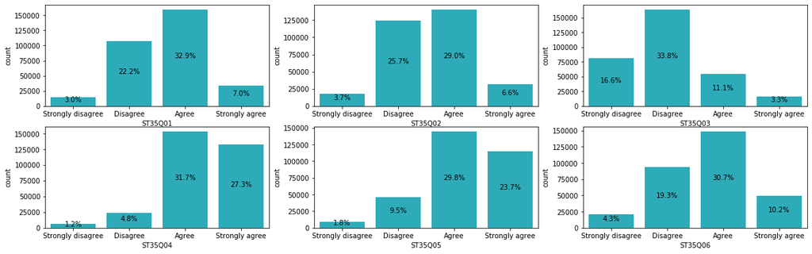

```python
# plots comparing the different features - nan values are excluded
plt.figure(figsize=[20, 6])
plt.subplot(2,3,1)
sb.countplot(data = pisa, x = 'ST35Q01', color=base_color) # Most of my friends do well in mathematics
pct_labels('ST35Q01')
plt.subplot(2,3,2)
sb.countplot(data = pisa, x = 'ST35Q02', color=base_color) # Most of my friends work hard at mathematics
pct_labels('ST35Q02')
plt.subplot(2,3,3)
sb.countplot(data = pisa, x = 'ST35Q03', color=base_color) # My friends enjoy taking mathematics tests
pct_labels('ST35Q03')
plt.subplot(2,3,4)
sb.countplot(data = pisa, x = 'ST35Q04', color=base_color) # My parents believe it’s important for me to study mathematics
pct_labels('ST35Q04')
plt.subplot(2,3,5)
sb.countplot(data = pisa, x = 'ST35Q05', color=base_color) # My parents believe that mathematics is important for my career
pct_labels('ST35Q05')
plt.subplot(2,3,6)
sb.countplot(data = pisa, x = 'ST35Q06', color=base_color) # My parents like mathematics
pct_labels('ST35Q06')
```

The less agreed statement is "My friends enjoy taking mathematics tests" (ST35Q03).  
The most agreed statements are: "My parents believe it’s important for me to study mathematics" (ST35Q04) and "My parents believe that mathematics is important for my career" (ST35Q05).

### Instrumental Motivation for Mathematics (INSTMOT)

#### Information from Pisa 2012 Technical Report:

Table 16.10 item parameters for instrumental motivation for mathematics (INSTMOT):  
Four items measuring instrumental motivation for mathematics (INSTMOT) were used in the Main Survey of PISA 2012 as well as for PISA 2003. Table 16.10 shows the item wording and the international item parameters for this scale. The response categories vary from “Strongly Agree”, “Agree”, “Disagree”, to “Strongly disagree”. All items were reversed, so the higher difficulty corresponds to the higher level of motivation. For this index, item difficulties do not vary considerably.

Thinking about your views on mathematics: to what extent do you agree with the following statements?  
ST29Q02 b) Making an effort in mathematics is worth it because it will help me in the work that I want to do later on  
ST29Q05 e) Learning mathematics is worthwhile for me because it will improve my career <prospects, chances>  
ST29Q07 g) Mathematics is an important subject for me because I need it for what I want to study later on  
ST29Q08 h) I will learn many things in mathematics that will help me get a job

Items were reversely recoded as (4=0), (3=1), (2=2), (1=3).Total score was calculated as a ratio of a sum of all questions over maximum score of valid responses (questions with missing value did not contribute to max score).

Let's first analyse the data of this column:

```python
pisa['INSTMOT'].dtype
```

```
dtype('O')
```

```python
# change datatype to float
change_to_float('INSTMOT')
```

```python
pisa['INSTMOT'].describe()
```

```
count    316322.000000
mean          0.108456
std           0.983542
min          -2.300000
25%          -0.670000
50%           0.050000
75%           0.800000
max           1.590000
Name: INSTMOT, dtype: float64
```

```python
# sample of the columns belonging to INSTMOT
cols_instmot = ['ST29Q02', 'ST29Q05', 'ST29Q07', 'ST29Q08']
pisa[pisa['INSTMOT'] == pisa['INSTMOT'].max()][cols_instmot].head()
```

|  | ST29Q02 | ST29Q05 | ST29Q07 | ST29Q08 |
| --- | --- | --- | --- | --- |
| 2 | Strongly agree | Strongly agree | Strongly agree | Strongly agree |
| 4 | Strongly agree | Strongly agree | Strongly agree | Strongly agree |
| 11 | Strongly agree | Strongly agree | Strongly agree | Strongly agree |
| 12 | Strongly agree | Strongly agree | Strongly agree | Strongly agree |
| 15 | Strongly agree | Strongly agree | Strongly agree | Strongly agree |

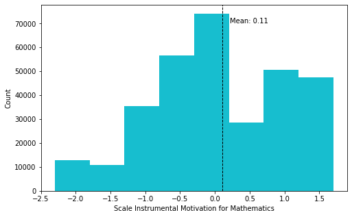

```python
# standard-scaled plot
binsize = 0.5
bins = np.arange(pisa['INSTMOT'].min(), pisa['INSTMOT'].max()+binsize, binsize)

plt.figure(figsize=[8, 5])
plt.hist(data = pisa, x = 'INSTMOT', bins = bins, color=base_color)
plt.axvline(pisa['INSTMOT'].mean(), color='k', linestyle='dashed', linewidth=1)
min_ylim, max_ylim = plt.ylim()
plt.text(pisa['INSTMOT'].mean()*2, max_ylim*0.9, 'Mean: {:.2f}'.format(pisa['INSTMOT'].mean()))
plt.xlabel('Scale Instrumental Motivation for Mathematics')
plt.ylabel('Count')
plt.show()
```

A higher value on the scale means higher motivation in mathematics.  
The distribution looks bimodal, which hasn't a deeper signification in my opinion.  
Let's take a closer look at the single features belonging to INSTMOT:

```python
# unique values in column
pisa['ST29Q07'].unique()
```

```
array(['Agree', 'Disagree', 'Strongly agree', nan, 'Strongly disagree'],
      dtype=object)
```

```python
# data preparation - Change values into categorical data
level_order = ['Strongly disagree', 'Disagree', 'Agree', 'Strongly agree']
ordered_cat = pd.api.types.CategoricalDtype(ordered=True, categories = level_order)
pisa[cols_instmot] = pisa[cols_instmot].astype(ordered_cat)
```

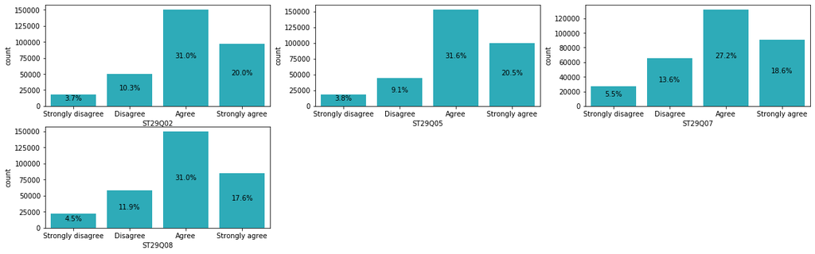

```python
#  plots comparing the different features - nan values are excluded
plt.figure(figsize=[20, 6])
plt.subplot(2,3,1)
sb.countplot(data = pisa, x = 'ST29Q02', color=base_color) # Making an effort in mathematics is worth it because it will help me in the work that I want to do later on
pct_labels('ST29Q02')
plt.subplot(2,3,2)
sb.countplot(data = pisa, x = 'ST29Q05', color=base_color) # Learning mathematics is worthwhile for me because it will improve my career <prospects, chances>
pct_labels('ST29Q05')
plt.subplot(2,3,3)
sb.countplot(data = pisa, x = 'ST29Q07', color=base_color) #  Mathematics is an important subject for me because I need it for what I want to study later on
pct_labels('ST29Q07')
plt.subplot(2,3,4)
sb.countplot(data = pisa, x = 'ST29Q08', color=base_color) # I will learn many things in mathematics that will help me get a job
pct_labels('ST29Q08')
```

All statements here have been more approved than negated. Most agreed statement is (ST29Q05) "Learning mathematics is worthwhile for me because it will improve my career <prospects, chances>"

### Item parameters for mathematics interest (INTMAT)

#### Information from Pisa 2012 Technical Report:

Table 16.9 item parameters for mathematics interest (INTMAT):  
Four items measuring mathematics interest (INTMAT) were used in the Main Survey of PISA 2012 as well as for PISA 2003. Table 16.9 shows the item wording and the international item parameters for this scale. The response categories were “Strongly agree”, “Agree”, “Disagree” and “Strongly disagree”. All items were reversed so that the higher difficulty corresponds to a higher level of interest. For this index, item difficulties vary from a comparatively easy one “I am interested in the things I learn in mathematics” (d = -0.87) to a more difficult “I enjoy reading about mathematics” (d = 0.52). This indicates that even those students who are interested in the things they learn in mathematics do not necessarily read about mathematics.

Thinking about your views on mathematics: to what extent do you agree with the following statements?  
ST29Q01 a) I enjoy reading about mathematics  
ST29Q03 c) I look forward to my mathematics lessons  
ST29Q04 d) I do mathematics because I enjoy it  
ST29Q06 f) I am interested in the things I learn in mathematics

Items were reversely recoded as (4=0),(3=1),(2=2),(1=3).Total score was calculated as a ratio of a sum of all questions over maximum score of valid responses (questions with missing value did not contribute to max score).

Let's first analyse the data of this column:

```python
pisa['INTMAT'].dtype
```

```
dtype('O')
```

```python
# change datatype to float
change_to_float('INTMAT')
```

```python
pisa['INTMAT'].describe()
```

```
count    316708.000000
mean          0.212424
std           1.004716
min          -1.780000
25%          -0.340000
50%           0.300000
75%           0.910000
max           2.290000
Name: INTMAT, dtype: float64
```

```python
# sample of the columns belonging to INTMAT
cols_intmat = ['ST29Q01', 'ST29Q03', 'ST29Q04', 'ST29Q06']
pisa[pisa['INTMAT'] == pisa['INTMAT'].min()][cols_intmat].head()
```

|  | ST29Q01 | ST29Q03 | ST29Q04 | ST29Q06 |
| --- | --- | --- | --- | --- |
| 320 | Strongly disagree | Strongly disagree | Strongly disagree | Strongly disagree |
| 360 | Strongly disagree | Strongly disagree | Strongly disagree | Strongly disagree |
| 514 | Strongly disagree | Strongly disagree | Strongly disagree | Strongly disagree |
| 527 | Strongly disagree | Strongly disagree | Strongly disagree | Strongly disagree |
| 782 | Strongly disagree | Strongly disagree | Strongly disagree | Strongly disagree |

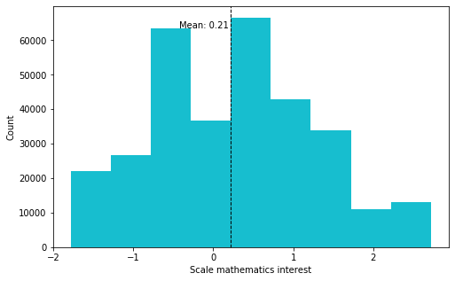

```python
# standard-scaled plot
binsize = 0.5
bins = np.arange(pisa['INTMAT'].min(), pisa['INTMAT'].max()+binsize, binsize)

plt.figure(figsize=[8, 5])
plt.hist(data = pisa, x = 'INTMAT', bins = bins, color=base_color)
plt.axvline(pisa['INTMAT'].mean(), color='k', linestyle='dashed', linewidth=1)
min_ylim, max_ylim = plt.ylim()
plt.text(pisa['INTMAT'].mean()*-2, max_ylim*0.91, 'Mean: {:.2f}'.format(pisa['INTMAT'].mean()))
plt.xlabel('Scale mathematics interest')
plt.ylabel('Count')
plt.show()
```

A higher value on the scale means higher interest in mathematics. From all features we observed so long, interest in mathematics has the highest mean.  
Let's take a closer look at the individual characteristics that belong to INTMAT:

```python
# unique values in column
pisa['ST29Q04'].unique()
```

```
array(['Agree', 'Disagree', nan, 'Strongly agree', 'Strongly disagree'],
      dtype=object)
```

```python
# data preparation - Change values into categorical data
level_order = ['Strongly disagree', 'Disagree', 'Agree', 'Strongly agree']
ordered_cat = pd.api.types.CategoricalDtype(ordered=True, categories = level_order)
pisa[cols_intmat] = pisa[cols_intmat].astype(ordered_cat)
```

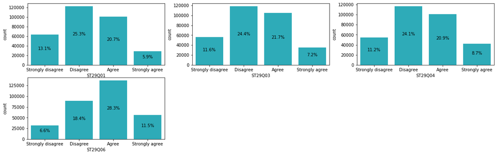

```python
# plots comparing the different features - nan values are excluded
plt.figure(figsize=[20, 6])
plt.subplot(2,3,1)
sb.countplot(data = pisa, x = 'ST29Q01', color=base_color) # I enjoy reading about mathematics
pct_labels('ST29Q01')
plt.subplot(2,3,2)
sb.countplot(data = pisa, x = 'ST29Q03', color=base_color) # I look forward to my mathematics lessons
pct_labels('ST29Q03')
plt.subplot(2,3,3)
sb.countplot(data = pisa, x = 'ST29Q04', color=base_color) #  I do mathematics because I enjoy it
pct_labels('ST29Q04')
plt.subplot(2,3,4)
sb.countplot(data = pisa, x = 'ST29Q06', color=base_color) # I am interested in the things I learn in mathematics
pct_labels('ST29Q06')
```

### Home educational resources (HEDRES)

#### Information from Pisa 2012 Technical Report:

Home educational resources In your home, do you have:  
ST26Q01 A desk to study at  
ST26Q03 A quiet place to study  
ST26Q04 A computer you can use for school work  
ST26Q05 Educational software

All items were recoded as (Yes=1, No=0). Total score was calculated as a ratio of a sum of all items over maximum score of valid responses (items with missing value did not contribute to max score).

Let's first analyse the data of this column:

```python
pisa['HEDRES'].dtype
```

```
dtype('O')
```

```python
# change datatype to float
change_to_float('HEDRES')
```

```python
pisa['HEDRES'].describe()
```

```
count    477772.000000
mean         -0.195442
std           1.074053
min          -3.930000
25%          -0.690000
50%           0.040000
75%           1.120000
max           1.120000
Name: HEDRES, dtype: float64
```

```python
# sample of the columns belonging to HEDRES
cols_hedres = ['ST26Q01', 'ST26Q03', 'ST26Q04', 'ST26Q05']
pisa[pisa['HEDRES'] == pisa['HEDRES'].max()][cols_hedres].head()
```

|  | ST26Q01 | ST26Q03 | ST26Q04 | ST26Q05 |
| --- | --- | --- | --- | --- |
| 1 | Yes | Yes | Yes | Yes |
| 10 | Yes | Yes | Yes | Yes |
| 35 | Yes | Yes | Yes | Yes |
| 38 | Yes | Yes | Yes | Yes |
| 39 | Yes | Yes | Yes | Yes |

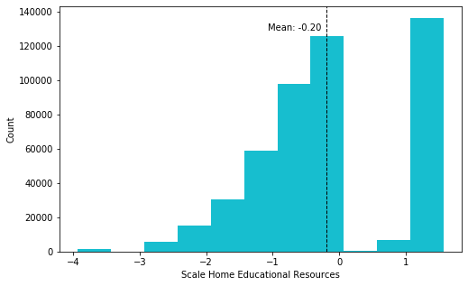

```python
# standard-scaled plot
binsize = 0.5
bins = np.arange(pisa['HEDRES'].min(), pisa['HEDRES'].max()+binsize, binsize)

plt.figure(figsize=[8, 5])
plt.hist(data = pisa, x = 'HEDRES', bins = bins, color=base_color)
plt.axvline(pisa['HEDRES'].mean(), color='k', linestyle='dashed', linewidth=1)
min_ylim, max_ylim = plt.ylim()
plt.text(pisa['HEDRES'].mean()*5.5, max_ylim*0.9, 'Mean: {:.2f}'.format(pisa['HEDRES'].mean()))
plt.xlabel('Scale Home Educational Resources')
plt.ylabel('Count')
plt.show()
```

A higher value on the scale means more home educational resources available. From all features we observed so far, this is the one with the lowest mean.  
Let's take a closer look at the individual characteristics that belong to HEDRES:

```python
# unique values in column
pisa['ST26Q04'].unique()
```

```
array(['No', 'Yes', nan], dtype=object)
```

```python
# data preparation - Change values into categorical data
level_order = ['Yes', 'No']
ordered_cat = pd.api.types.CategoricalDtype(ordered=True, categories = level_order)
pisa[cols_hedres] = pisa[cols_hedres].astype(ordered_cat)
```

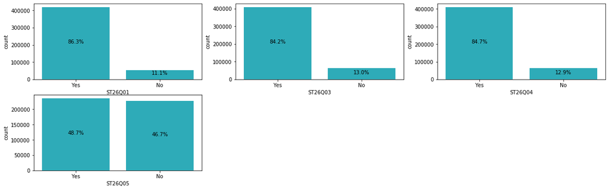

```python
# plots comparing the different features - nan values are excluded
plt.figure(figsize=[20, 6])
plt.subplot(2,3,1)
sb.countplot(data = pisa, x = 'ST26Q01', color=base_color) # A desk to study at
pct_labels('ST26Q01')
plt.subplot(2,3,2)
sb.countplot(data = pisa, x = 'ST26Q03', color=base_color) # A quiet place to study
pct_labels('ST26Q03')
plt.subplot(2,3,3)
sb.countplot(data = pisa, x = 'ST26Q04', color=base_color) # A computer you can use for school work
pct_labels('ST26Q04')
plt.subplot(2,3,4)
sb.countplot(data = pisa, x = 'ST26Q05', color=base_color) # Educational software
pct_labels('ST26Q05')
```

A vast majority of students (> 84%) have a desk, a quite place and a computer. But only 48% have educational software. This last feature probably pulls down the mean.

### Out of school lessons in mathematics (ST55Q02)

#### Information from Pisa 2012 Technical Report:

The item was recoded as (‘1’=0), (‘2’=1), (‘3’=3), (‘4’=5), (‘5’=7), representing an approximate time in hours.

```python
# unique values in column
pisa['ST55Q02'].unique()
```

```
array([nan, '2 or more but less than 4 hours a week',
       'I do not attend <out-of-school time lessons> in this subject',
       'Less than 2 hours a week', '6 or more hours a week',
       '4 or more but less than 6 hours a week'], dtype=object)
```

```python
# data preparation - Change values into categorical data
level_order = ['I do not attend <out-of-school time lessons> in this subject', 'Less than 2 hours a week', '2 or more but less than 4 hours a week', '4 or more but less than 6 hours a week', '6 or more hours a week']
ordered_cat = pd.api.types.CategoricalDtype(ordered=True, categories = level_order)
pisa['ST55Q02'] = pisa['ST55Q02'].astype(ordered_cat)
```

```python
# function to add percentages into the plotbars (y-axis)
def pct_labels_y(col):
    cat_counts = pisa[col].value_counts()
    locs, labels = plt.yticks()
    for loc, label in zip(locs, labels):
        count=cat_counts[label.get_text()]
        pct_string = '{:0.1f}%'.format(100*count/n_points)
        plt.text(count+1000, loc, pct_string)
```

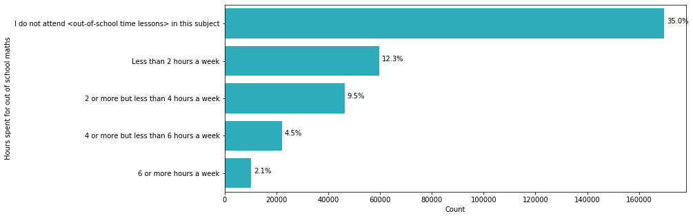

```python
# standard-scaled plot - nan values are excluded
plt.figure(figsize=[12, 5])
sb.countplot(data = pisa,y = 'ST55Q02', color=base_color)
plt.xlabel('Count')
plt.ylabel('Hours spent for out of school maths')
pct_labels_y('ST55Q02')
```

More than half of the sudents who answered this question do not attend mathematics classes outside school.

### Students’ responses regarding parental education (MISCED & FISCED)

#### Information from Pisa 2012 Technical Report:

Students’ responses regarding parental education were classified using ISCED (OECD, 1999). Indices on parental education were constructed by recoding educational qualifications into the following categories: (0) None, (1) ISCED 1 (primary education), (2) ISCED 2 (lower secondary), (3) ISCED Level 3B or 3C (vocational/pre-vocational upper secondary), (4) ISCED 3A (general upper secondary) and/or ISCED 4 (non-tertiary post-secondary), (5) ISCED 5B (vocational tertiary) and (6) ISCED 5A, 6 (theoretically oriented tertiary and post-graduate). Indices with these categories were provided for the students’ mother (MISCED) and the students’ father (FISCED).

```python
# unique values in columns
pisa['MISCED'].unique(), pisa['FISCED'].unique()
```

```
(array(['ISCED 3A, ISCED 4', 'ISCED 5A, 6', 'ISCED 3B, C', 'None',
        'ISCED 2', 'ISCED 1', 'ISCED 5B', nan], dtype=object),
 array(['ISCED 3A, ISCED 4', 'ISCED 5A, 6', 'ISCED 2', 'None', 'ISCED 5B',
        'ISCED 3B, C', 'ISCED 1', nan], dtype=object))
```

```python
# data preparation - Change values into categorical data
level_order = ['None', 'ISCED 1', 'ISCED 2', 'ISCED 3B, C', 'ISCED 3A, ISCED 4', 'ISCED 5B', 'ISCED 5A, 6']
ordered_cat = pd.api.types.CategoricalDtype(ordered=True, categories = level_order)
pisa[['MISCED', 'FISCED']] = pisa[['MISCED', 'FISCED']].astype(ordered_cat)
```

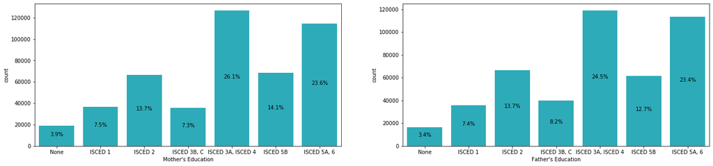

```python
# standard-scaled plot - nan values are excluded
plt.figure(figsize=[23, 5])
plt.subplot(1,2,1)
sb.countplot(data = pisa,x = 'MISCED', color=base_color)
plt.xlabel('Mother\'s Education')
pct_labels('MISCED')
plt.subplot(1,2,2)
sb.countplot(data = pisa,x = 'FISCED', color=base_color)
plt.xlabel('Father\'s Education')
pct_labels('FISCED')
```

As we can see, both distributions are very similar, with a peak at ISCED 3A (general upper secondary) and/or ISCED 4 (non-tertiary post-secondary), closely followed by ISCED 5A, 6 (theoretically oriented tertiary and post-graduate).

### How many books at home (ST28Q01)

#### Information from Pisa 2012 Technical Report:

The variables comprising ESCS for PISA 2012 included: home possessions (HOMEPOS) – which comprised all items on the WEALTH, CULTPOS and HEDRES scales, as well as books in the home (ST28Q01) recoded into a four-level categorical variable (fewer than or equal to 25 books, 26-100 books, 101-500 books, more than 500 books).

```python
# unique values in columns
pisa['ST28Q01'].unique()
```

```
array(['0-10 books ', '201-500 books ', 'More than 500 books',
       '11-25 books ', '101-200 books ', '26-100 books ', nan],
      dtype=object)
```

```python
# data preparation - Change values into categorical data
level_order = ['0-10 books ', '11-25 books ', '26-100 books ', '101-200 books ', '201-500 books ', 'More than 500 books']
ordered_cat = pd.api.types.CategoricalDtype(ordered=True, categories = level_order)
pisa['ST28Q01'] = pisa['ST28Q01'].astype(ordered_cat)
```

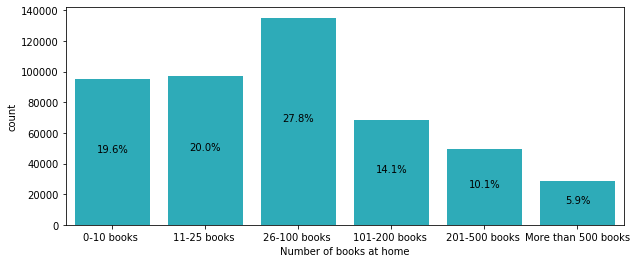

```python
# standard-scaled plot - nan values are excluded
plt.figure(figsize=[10, 4])
sb.countplot(data = pisa, x = 'ST28Q01', color=base_color)
pct_labels('ST28Q01')
plt.xlabel('Number of books at home');
```

A majority of students have less than 100 books at home.

### Conclusion of the univariate exploration

We observed a number of variables, a large majority of which are quantitative. The particular feature of these quantitative variables is that they can be broken down into categorical variables.  
Most of the datatypes were changed, either as float for quantitative variables or categorical for the qualitative variables.  
All nan values have been excluded from the analysis.

## Bivariate Exploration

Let's start with a comparison of the mathematics scores with the categorical variables in the dataset:

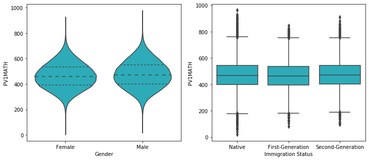

```python
# comparison of mathematics scores with gender // with immigration status
plt.figure(figsize=[12, 5])
plt.subplot(1,2,1)
sb.violinplot(data=pisa, x='ST04Q01', y='PV1MATH', color=base_color, inner='quartile')
plt.xlabel('Gender')
plt.subplot(1,2,2)
sb.boxplot(data=pisa, x='IMMIG', y='PV1MATH', color=base_color)
plt.xlabel('Immigration Status');
```

There is here no apparent relationship between mathematics scores and gender or immigration status.

Let's now observe the relationship between mathematic scores and extracurricular mathematic hours:

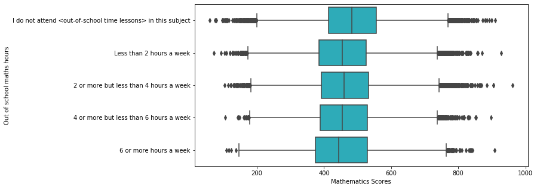

```python
# mathematics score versus out of school mathematics hours
plt.figure(figsize=[10, 5])
sb.boxplot(data=pisa, x='PV1MATH', y='ST55Q02', color=base_color)
plt.xlabel('Mathematics Scores')
plt.ylabel('Out of school maths hours');
```

This is a very interesting observation: the less students take mathematics hours outside school, the better the mathematics scores in average.

Next variable to observe is the parental education. Let's see if there's a relationship to math scores:

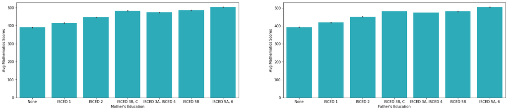

```python
#Students’ responses regarding parental education ('MISCED' & 'FISCED') versus average mathematic score
plt.figure(figsize=[25, 5])
plt.subplot(1, 2, 1)
sb.barplot(data=pisa, x='MISCED', y='PV1MATH', color=base_color)
plt.xlabel('Mother\'s Education')
plt.ylabel('Avg Mathematics Scores')
plt.subplot(1, 2, 2)
sb.barplot(data=pisa, x='FISCED', y='PV1MATH', color=base_color)
plt.xlabel('Father\'s Education')
plt.ylabel('Avg Mathematics Scores');
```

There is an upward trend here for both parents: the mathematics scores seems to be influenced seem to be influenced by the educational level of the parents.

Our last categorical variable is the number of books at home. Let's look at the relationship to the mathematics scores:

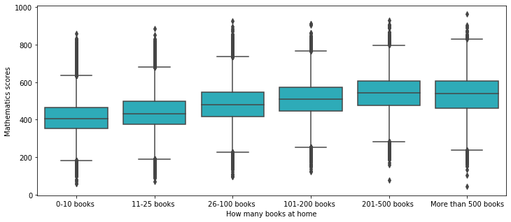

```python
plt.figure(figsize=[12, 5])
sb.boxplot(data=pisa, x='ST28Q01', y='PV1MATH', color=base_color)
plt.xlabel('How many books at home')
plt.ylabel('Mathematics scores');
```

It's very interesting to see how the number of books at home relates to mathematics scores: the more books the students have at home, the better their mathematics scores.

Now, let's have a look at the correlations between the quantitatives variables of the dataset:

```python
numeric_vars = ['FAILMAT','ANXMAT', 'SUBNORM', 'INSTMOT', 'INTMAT', 'HEDRES','PV1MATH']
```

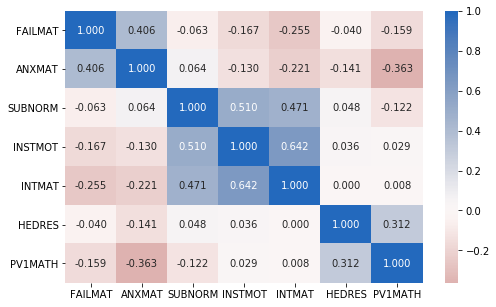

```python
# correlation plot
plt.figure(figsize = [8, 5])
sb.heatmap(pisa[numeric_vars].corr(), annot = True, fmt = '.3f', cmap = 'vlag_r', center = 0)
plt.show()
```

We can see here, that the mathematics scores (PV1MATH) have a negative relationship to mathematics anxiety (ANXMAT) which has a quite strong positive relationship to attributions to failure in mathematics (FAILMAT). On the other side, we can see a positive relationship between mathematics scores and home educational resources (HEDRES). It's interesting to see that there seems to be no (or very low) relationship between mathematics scores and mathematics interest (INTMAT) or instrumental motivation for mathematics (INSTMOT). Both features and subjective norms in mathematics (SUBNORM) have quite strong positive relationships among each others (which we'll not analyse further because of the lack of relationship to mathematics scores).

Let's first have a look to the relationship between mathematics anxiety (ANXMAT) and mathematics scores (PV1MATH):

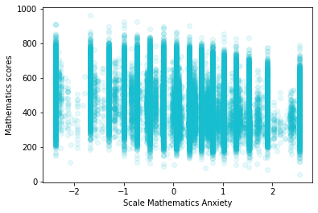

```python
# scatterplot showing relationship between mathematics scores and mathematics anxiety
plt.scatter(data = pisa, x='ANXMAT', y='PV1MATH', alpha=1/10, color=base_color)
plt.xlabel('Scale Mathematics Anxiety')
plt.ylabel('Mathematics scores');
```

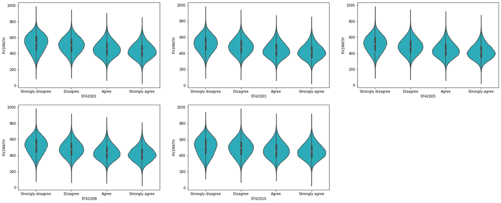

```python
# Comparison of all mathematics anxiety variables to mathematics score
plt.figure(figsize=[25, 10])
plt.subplot(2,3,1)
sb.violinplot(data=pisa, x='ST42Q01', y='PV1MATH', color=base_color) #I often worry that it will be difficult for me in mathematics classes
plt.subplot(2,3,2)
sb.violinplot(data=pisa, x='ST42Q03', y='PV1MATH', color=base_color) #I get very tense when I have to do mathematics homework
plt.subplot(2,3,3)
sb.violinplot(data=pisa, x='ST42Q05', y='PV1MATH', color=base_color) #I get very nervous doing mathematics problems
plt.subplot(2,3,4)
sb.violinplot(data=pisa, x='ST42Q08', y='PV1MATH', color=base_color) #I feel helpless when doing a mathematics problem
plt.subplot(2,3,5)
sb.violinplot(data=pisa, x='ST42Q10', y='PV1MATH', color=base_color); #I worry that I will get poor in mathematics
```

The relationship of all features to mathematics scores is very similar: the more strongly a statement was agreed to, the lower the mathematics score.

Now, let's have a closer look to the positive relationship between mathematics scores (PV1MATH) and home education resources (HEDRES):

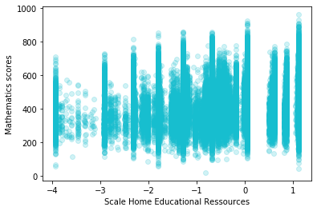

```python
# scatterplot showing relationship between home educational resources and mathematics scores
plt.scatter(data = pisa, x='HEDRES', y='PV1MATH', alpha=1/5, color=base_color)
plt.xlabel('Scale Home Educational Ressources')
plt.ylabel('Mathematics scores');
```

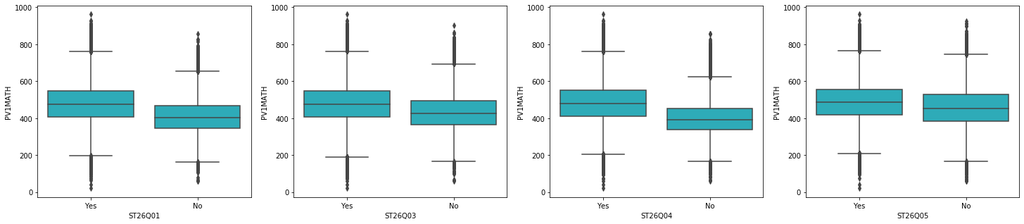

```python
# Comparison of all home educational resources to mathematics score
plt.figure(figsize=[25, 5])
plt.subplot(1,4,1)
sb.boxplot(data=pisa, x='ST26Q01', y='PV1MATH', color=base_color) #A desk to study at
plt.subplot(1,4,2)
sb.boxplot(data=pisa, x='ST26Q03', y='PV1MATH', color=base_color) #A quiet place to study
plt.subplot(1,4,3)
sb.boxplot(data=pisa, x='ST26Q04', y='PV1MATH', color=base_color) #A computer you can use for school work
plt.subplot(1,4,4)
sb.boxplot(data=pisa, x='ST26Q05', y='PV1MATH', color=base_color) #Educational software
```

A desk to study (ST26Q01) at and a computer (ST26Q04) seem to have biggest impacts on mathematics scores. It's interesting to note that educational software (ST26Q05) does not have the greatest influence on mathematics scores. This is an interesting finding since we have seen previously that about half of the students do not use educational software at home.

The feature attributions to failure in mathematics (FAILMAT) has a weak negative relationship to mathematics scores (PV1MATH). Let's see if we can find any useful information though:

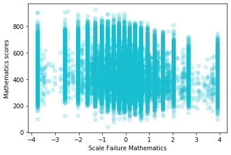

```python
# scatterplot showing relationship between attribution to failure and mathematics scores
plt.scatter(data = pisa, x='FAILMAT', y='PV1MATH', alpha=1/5, color=base_color)
plt.xlabel('Scale Failure Mathematics')
plt.ylabel('Mathematics scores');
```

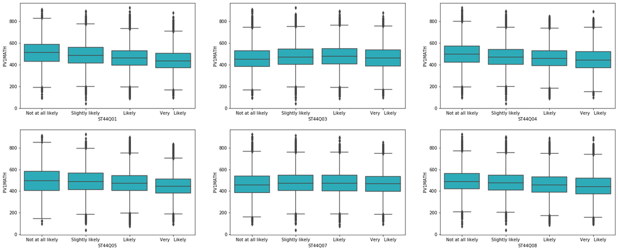

```python
# Comparison of all attributions to failure in mathematics to mathematics scores
plt.figure(figsize=[25, 10])
plt.subplot(2,3,1)
sb.boxplot(data=pisa, x='ST44Q01', y='PV1MATH', color=base_color) #I’m not very good at solving mathematics problems
plt.subplot(2,3,2)
sb.boxplot(data=pisa, x='ST44Q03', y='PV1MATH', color=base_color) #My teacher did not explain the concepts well this week
plt.subplot(2,3,3)
sb.boxplot(data=pisa, x='ST44Q04', y='PV1MATH', color=base_color) #This week I made bad guesses on the quiz
plt.subplot(2,3,4)
sb.boxplot(data=pisa, x='ST44Q05', y='PV1MATH', color=base_color) #Sometimes the course material is too hard
plt.subplot(2,3,5)
sb.boxplot(data=pisa, x='ST44Q07', y='PV1MATH', color=base_color) #The teacher did not get students interested in the material
plt.subplot(2,3,6)
sb.boxplot(data=pisa, x='ST44Q08', y='PV1MATH', color=base_color); #Sometimes I am just unlucky
```

Apparently, according to the student's answers, failures in mathematics are due more to the student himself (ST44Q01 'I’m not very good at solving mathematics problems' and ST44Q04 'This week I made bad guesses on the quiz') than to the teacher (ST44Q03 'My teacher did not explain the concepts well this week' and ST44Q07 'The teacher did not get students interested in the material').

We're not going to analyse the variable FAILMAT further, because it can't really deliver us an explanation for the mathematics scores. This variable only deals with students' assumptions, which are inherently subjective.

Let's take a look if we can find another variable that has a relationship to mathematics anxiety:

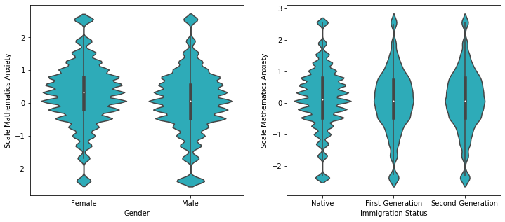

```python
# Mathematics Anxiety versus Gender // Mathematics Anxiety versus Immigration status
plt.figure(figsize=[12, 5])
plt.subplot(1,2,1)
sb.violinplot(data=pisa, x='ST04Q01', y='ANXMAT', color=base_color)
plt.ylabel('Scale Mathematics Anxiety')
plt.xlabel('Gender')

plt.subplot(1,2,2)
sb.violinplot(data=pisa, x='IMMIG', y='ANXMAT', color=base_color)
plt.ylabel('Scale Mathematics Anxiety')
plt.xlabel('Immigration Status');
```

Female students seems to be more concerned by mathematics anxiety. On the other side, immigration status doesn't seem to have any influence on mathematics anxiety.

Next, let's take a look if extracurricular mathematics hours have an impact on mathematic anxiety:

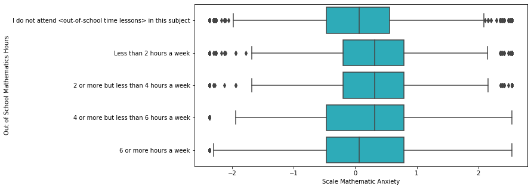

```python
# Mathematics anxiety versus Out of school maths hours
plt.figure(figsize=[10, 5])
sb.boxplot(data=pisa, x='ANXMAT', y='ST55Q02', color=base_color)
plt.ylabel('Out of School Mathematics Hours')
plt.xlabel('Scale Mathematic Anxiety');
```

It's very interesting to observe that students who don't attend extra hours are less anxious than the students who attend extracurricular mathematics hours. An exception is the group of students who take six or more hours a week: The mean anxiety rate of this group is similar to the group who don't attend extra hours.